# Week 10: Final Exam Review

ISM4641 - Python for Business Analytics

Dr. Tim Smith

University of South Florida

2026-04-01

## What This Review Covers

The final exam covers the **second half** of the course — everything since the midterm:

| Week | Topic |
| --- | --- |
| **Week 5** | Pandas DataFrames and Data Manipulation |
| **Week 6** | Data Visualization with Matplotlib |
| **Week 7** | Descriptive and Inferential Statistics |
| **Week 8** | Linear Regression |
| **Week 9** | Logistic Regression and Classification |

## Today’s Agenda

1. Week 5 Review — Pandas Essentials
2. Week 6 Review — Visualization Essentials
3. Week 7 Review — Hypothesis Testing
4. Week 8 Review — Linear Regression
5. Week 9 Review — Logistic Regression
6. **Deep Dive: The Confusion Matrix and Picking the Right Metric**
7. Exam Format and Study Tips

# Week 5: Pandas

## Two Core Data Structures

| Structure | Shape | Think of it as |
| --- | --- | --- |
| **Series** | 1D labeled array | A single column |
| **DataFrame** | 2D labeled table | An entire spreadsheet |

A DataFrame is a collection of Series — one per column.

```python
import pandas as pd
sales = pd.DataFrame({
    'Product': ['A', 'B', 'C'],
    'Revenue': [250, 180, 320],
    'Units':   [50,  30,  80]
})
print(sales)
print(f"\nShape: {sales.shape}")
```

```
  Product  Revenue  Units
0       A      250     50
1       B      180     30
2       C      320     80

Shape: (3, 3)
```

## Reading and Writing Data

```python
# Read CSV (most common)
df = pd.read_csv('sales.csv')

# Read from URL
df = pd.read_csv('https://example.com/data.csv')

# Save a DataFrame to CSV
df.to_csv('output.csv', index=False)
```

**Remember:** `index=False` prevents pandas from writing the row index as an extra column.

## Selecting Columns

```python
df['Revenue']            # Single column → returns Series
df[['Revenue', 'Units']] # Multiple columns → returns DataFrame
```

| Selection | Returns |
| --- | --- |
| `df['col']` (single brackets, one name) | **Series** |
| `df[['col']]` (double brackets) | **DataFrame** (one-column) |
| `df[['a','b','c']]` (double brackets, list) | **DataFrame** |

**Watch for the double-bracket rule** — `fit()` and `predict()` in scikit-learn expect a 2D `X`, so always use `df[['feature']]`.

## Selecting Rows: `loc` vs `iloc`

|  | `loc` | `iloc` |
| --- | --- | --- |
| **Based on** | Labels | Integer positions |
| **End of slice** | Inclusive | Exclusive (like Python) |
| **Example** | `df.loc[0:2]` → rows with labels 0, 1, **and 2** | `df.iloc[0:2]` → rows at positions 0 and 1 |

```python
df.loc[0, 'Product']          # Row label 0, column 'Product'
df.loc[0:2, ['Product','Revenue']]  # Labels 0-2, two columns
df.iloc[0]                    # First row (by position)
df.iloc[:3, :2]               # First 3 rows, first 2 cols
```

## Boolean Filtering

```python
# Single condition
high_sales = df[df['Revenue'] > 200]

# Combined conditions — each condition in parentheses
df[(df['Revenue'] > 200) & (df['Units'] < 100)]

# 'or' uses | (pipe), 'and' uses &, 'not' uses ~
df[(df['Region'] == 'West') | (df['Region'] == 'East')]
```

**Rules:**

- Use `&`, `|`, `~` — NOT `and`, `or`, `not`
- Wrap each condition in parentheses `()`

## Sorting and Adding Columns

```python
# Sort by a single column (ascending by default)
df.sort_values('Revenue', ascending=False)

# Sort by multiple columns
df.sort_values(['Region', 'Revenue'], ascending=[True, False])

# Add a new column (arithmetic on columns is element-wise)
df['Revenue_per_Unit'] = df['Revenue'] / df['Units']
```

## GroupBy: Split-Apply-Combine

```python
# "What's the average revenue per region?"
df.groupby('Region')['Revenue'].mean()

# Multiple aggregations
df.groupby('Region').agg({'Revenue': 'sum', 'Units': 'mean'})

# Group by multiple columns
df.groupby(['Region', 'Product'])['Revenue'].sum()
```

**Split-Apply-Combine:** split rows into groups → apply a function → combine results.

## Combining DataFrames

```python
# Concat — stack vertically (same columns) or horizontally
pd.concat([df_q1, df_q2], axis=0)   # stack rows
pd.concat([df_info, df_scores], axis=1)  # stack columns

# Merge — join on a shared key (like SQL JOIN)
pd.merge(orders, customers, on='CustomerID', how='inner')
```

| `how=` | Keeps |
| --- | --- |
| `inner` | Only rows with a matching key in **both** |
| `left` | All rows from left, matching from right |
| `right` | All rows from right, matching from left |
| `outer` | All rows from both (fills with NaN) |

# Week 6: Data Visualization

## Basic Plotting Workflow

```python
import matplotlib.pyplot as plt

plt.figure(figsize=(10, 5))
plt.plot(quarters, revenue)      # 1. Create the plot
plt.title('Quarterly Revenue')   # 2. Label it
plt.xlabel('Quarter')
plt.ylabel('Revenue ($K)')
plt.legend()
plt.show()                       # 3. Display
```

**Every business plot needs:** title, axis labels, legend (when there’s more than one series).

## Choosing the Right Chart

| Chart | Best For | Example Question |
| --- | --- | --- |
| **Line** | Trends over time | “How did revenue change over 12 months?” |
| **Bar** | Comparing categories | “Which region sold the most?” |
| **Scatter** | Relationships between 2 numeric vars | “Does ad spend relate to sales?” |
| **Histogram** | Distribution of ONE numeric variable | “How are customer ages distributed?” |
| **Pie** | Parts of a whole (few categories) | “What’s each product’s share?” |

**Histogram vs. Bar Chart:** histogram = bins of *one* numeric variable. Bar = values across *categories*.

## Common Chart Code Patterns

```python
# Line with markers
plt.plot(months, sales, marker='o', color='steelblue', label='2025')

# Bar chart with value labels
plt.bar(categories, values, color='coral')

# Scatter plot
plt.scatter(ad_spend, sales, alpha=0.7)

# Histogram (ONE variable, binned)
plt.hist(ages, bins=20, color='steelblue', edgecolor='white')

# Pie chart
plt.pie(shares, labels=products, autopct='%1.0f%%')

# Subplots (2 charts side by side)
fig, axes = plt.subplots(1, 2, figsize=(12, 4))
axes[0].plot(x, y)
axes[1].bar(categories, values)
```

## Plotting from Pandas

```python
# Direct from a DataFrame
df.plot(x='Month', y='Sales', kind='line')
df['Revenue'].plot(kind='hist', bins=20)
df.groupby('Region')['Sales'].sum().plot(kind='bar')
```

Common `kind=` values: `'line'`, `'bar'`, `'barh'`, `'hist'`, `'scatter'`, `'pie'`.

## Common Visualization Mistakes

- Using a **pie chart** with too many slices (hard to read — use bar)
- **Missing axis labels** or title
- **Truncated y-axis** that exaggerates small differences
- Using **different colors** for categories with no meaning
- Plotting **too many lines** on one chart (becomes spaghetti)

# Week 7: Hypothesis Testing

## The Central Limit Theorem

**If you draw many random samples and compute the mean of each, the distribution of those sample means is approximately normal** — *regardless of the original population’s shape* — as long as sample size is “large enough” (usually n ≥ 30).

**Why we care:** CLT is why hypothesis tests work. You take **one** sample and use it to make inferences because CLT tells you where your sample mean would fall on the normal distribution of all possible sample means.

## The T-Distribution

When the population standard deviation (σ) is unknown, we use the sample’s standard deviation (s) and the **t-distribution** instead of the normal (z) distribution.

**T-distribution facts:**

- Looks similar to the normal distribution, but has **fatter tails**
- Shape depends on **degrees of freedom** — for a one-sample t-test, df = n − 1 (one less than the sample size)
- As sample size grows (df gets bigger), t-distribution approaches the normal distribution
- Nearly always what you use in practice — populations rarely have known σ

**Quick check:** a one-sample t-test on 4 observations has df = 3 (very fat tails); on 31 observations it has df = 30 (nearly identical to normal). You don’t compute df by hand — `scipy` handles it.

## The Hypothesis Testing Framework

1. **State hypotheses**
   - H₀ (null): “No difference / the status quo”
   - H₁ (alternative): “There IS a difference”
2. **Choose α** (significance level, usually 0.05)
3. **Collect data** and compute test statistic
4. **Compute p-value**
5. **Decide:**
   - If **p < α** → reject H₀ (evidence of a real effect)
   - If **p ≥ α** → fail to reject H₀ (not enough evidence)

**P-value interpretation:** the probability of seeing your result (or more extreme) **if H₀ were true**.

## Three Common t-Tests

| Test | When to Use | scipy Function |
| --- | --- | --- |
| **One-sample** | Compare one sample’s mean to a known value | `stats.ttest_1samp(data, value)` |
| **Two-sample** | Compare means of two **independent** groups | `stats.ttest_ind(group1, group2)` |
| **Paired** | Compare **before/after** on the same subjects | `stats.ttest_rel(before, after)` |

**Decision rule (all three):** if p-value < α, reject H₀.

```python
from scipy import stats
t_stat, p_value = stats.ttest_1samp(delivery_times, 5.0)
if p_value < 0.05:
    print("Reject H0")
```

## Common Hypothesis Testing Mistakes

- **Thinking “fail to reject H₀” = “H₀ is true”** (you just don’t have enough evidence)  
  *Absence of evidence isn’t evidence of absence. You may have too small a sample, too much noise, or a true effect that’s just smaller than you can detect.*
- **Confusing statistical significance with business significance**  
  *A p-value tells you whether a difference is likely real. It says nothing about whether the difference is large enough to matter to the business.*
- **Using a two-sample test on paired data (loses statistical power)**  
  *When the same subject is measured twice (before/after), each subject acts as their own control. Ignoring the pairing throws away that structure — you’ll need a much larger sample to detect the same effect.*
- **Running many tests and only reporting the significant ones (p-hacking)**  
  *At α = 0.05, roughly 1 in 20 “significant” results are false alarms even when nothing real is happening. Run 20 tests and you expect one to look significant by chance alone.*

# Week 8: Linear Regression

## The Linear Regression Equation

$$y = \beta_0 + \beta_1 x_1 + \beta_2 x_2 + \dots + \beta_n x_n + \varepsilon$$

| Symbol | Name | What It Means |
| --- | --- | --- |
| **y** | Target | What you’re predicting (a continuous number) |
| **β₀** | Intercept | Predicted y when all features = 0 |
| **β₁, β₂, …** | Coefficients | Change in y per 1-unit change in that feature |
| **ε** | Error | The part the model can’t explain |

**OLS (Ordinary Least Squares)** finds coefficients that minimize the **sum of squared residuals** (the vertical distances from each point to the line).

## Model Quality: R² and RMSE

**R² (R-squared)** — fraction of variance in y explained by the model (0 to 1; higher is better).

| R² | Interpretation |
| --- | --- |
| 0.90+ | Excellent (rare in business) |
| 0.70–0.90 | Good |
| 0.50–0.70 | Moderate |
| < 0.30 | Poor |

**RMSE (Root Mean Squared Error)** — average prediction error **in the original units**. Lower is better. Easier to explain to stakeholders because it has units (dollars, minutes, etc.).

## Train-Test Split and Overfitting

**Overfitting** = model fits the training data too well and fails on new data.

**Symptom:** high R² on training set, much lower R² on test set.

```python
from sklearn.model_selection import train_test_split

X_train, X_test, y_train, y_test = train_test_split(
    X, y, test_size=0.2, random_state=42)
```

- `test_size=0.2` → 20% of data held out for testing
- `random_state=42` → same split every run (reproducibility)
- Returns **four** objects: X_train, X_test, y_train, y_test

## The scikit-learn Workflow

```python
from sklearn.linear_model import LinearRegression
from sklearn.metrics import r2_score, mean_squared_error
import numpy as np

X = df[['feature1', 'feature2']]   # 2D (double brackets!)
y = df['target']                   # 1D

X_train, X_test, y_train, y_test = train_test_split(X, y, test_size=0.2, random_state=42)

model = LinearRegression()
model.fit(X_train, y_train)         # learn coefficients
y_pred = model.predict(X_test)      # predict

r2   = r2_score(y_test, y_pred)
rmse = np.sqrt(mean_squared_error(y_test, y_pred))

model.intercept_   # β₀
model.coef_        # array of β₁, β₂, …
```

## Interpreting Coefficients

**Price = $100,000 + $150 × SqFt + $25,000 × Bedrooms − $2,000 × Age**

| Coefficient | Meaning (*holding all other features constant*) |
| --- | --- |
| $100,000 | Baseline price at SqFt = 0, Bedrooms = 0, Age = 0 |
| **+$150** | Each additional square foot adds $150 |
| **+$25,000** | Each additional bedroom adds $25K |
| **−$2,000** | Each year older reduces price by $2K |

**For a 2,000 sqft, 3-bedroom, 10-year-old house:** $100,000 + $150 × 2000 + $25,000 × 3 − $2,000 × 10 = **$455,000**

## Regression Pitfalls

- **Correlation ≠ causation** (the firefighter / fire-damage trap)
- **Extrapolation** — predicting outside the range of training data is unreliable
- **Not splitting data** — you’ll think the model is better than it is
- **Wrong problem type** — linear regression is for **continuous** outcomes. For yes/no, use **logistic regression**
- **Too many features relative to sample size** — invites overfitting

# Week 9: Logistic Regression

## When to Use Logistic Regression

|  | Linear Regression | Logistic Regression |
| --- | --- | --- |
| **Target** | Continuous number | Binary category (0/1) |
| **Output** | A value ($250K) | A probability (0.73) |
| **Question** | “How much?” | “Which category?” |
| **Example** | Predict house price | Predict loan default |

**The sigmoid function** takes any real number and squashes it into (0, 1) — that’s what turns a linear combination into a valid probability.

## predict vs predict_proba

```python
from sklearn.linear_model import LogisticRegression

model = LogisticRegression(max_iter=1000)
model.fit(X_train, y_train)

# Class labels (0 or 1)
y_pred  = model.predict(X_test)

# Probabilities for each class — column 1 is P(positive class)
y_proba = model.predict_proba(X_test)[:, 1]
```

- `predict()` → hard class labels (0 or 1)
- `predict_proba()` → probabilities (nuanced, useful for ranking risk)

## Odds Ratios — Interpreting Coefficients

Logistic regression coefficients are in **log-odds**, not directly interpretable. Convert them to odds ratios: **Odds Ratio = e^coefficient**

| Odds Ratio | Meaning | Quick interpretation |
| --- | --- | --- |
| **> 1** | Increases odds of positive outcome | (OR − 1) × 100% increase per unit |
| **= 1** | No effect | Feature doesn’t help |
| **< 1** | Decreases odds | (1 − OR) × 100% decrease per unit |

**Example:** SupportCalls has OR = 1.65 → each additional support call increases churn odds by about 65%.

## Handling Imbalanced Data

**When one class vastly outnumbers the other** (e.g., only 5% of loans default), a naive model can get 95% accuracy by predicting “no default” for everyone — and catch zero defaults.

**Two tools:**

```python
# 1. Stratified split — preserves class ratio in train/test
X_train, X_test, y_train, y_test = train_test_split(
    X, y, test_size=0.2, stratify=y, random_state=42)

# 2. Balanced class weights — penalize minority-class errors more
model = LogisticRegression(max_iter=1000, class_weight='balanced')
```

# The Confusion Matrix Deep Dive

## The Confusion Matrix

For binary classification, the confusion matrix has 4 cells:

|  | **Predicted: No** (0) | **Predicted: Yes** (1) |
| --- | --- | --- |
| **Actual: No** (0) | True Negative (TN) | False Positive (FP) |
| **Actual: Yes** (1) | False Negative (FN) | True Positive (TP) |

- **True Positive (TP):** predicted Yes, actually Yes ✓
- **True Negative (TN):** predicted No, actually No ✓
- **False Positive (FP):** predicted Yes, actually No ✗ — “false alarm” (Type I error)
- **False Negative (FN):** predicted No, actually Yes ✗ — “miss” (Type II error)

## Confusion Matrix — Visual Diagram

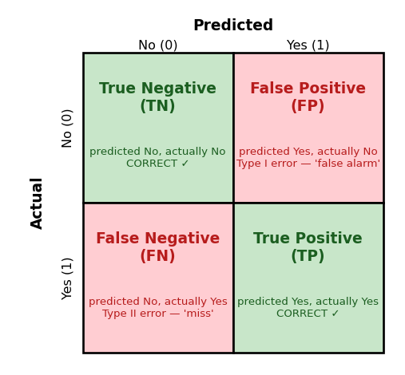

**Green cells = correct predictions.** **Red cells = errors.** The key question for any classification problem is: *which of the two red cells is more costly to my business?*

## The Four Core Metrics

| Metric | Formula | What it tells you |
| --- | --- | --- |
| **Accuracy** | (TP + TN) / Total | Overall fraction correct |
| **Precision** | TP / (TP + FP) | Of those we *flagged*, how many were correct? |
| **Recall** | TP / (TP + FN) | Of the actual positives, how many did we *catch*? |
| **F1 Score** | 2 × P × R / (P + R) | Harmonic mean — balances precision and recall |

**Memorize the formulas. Know which metric answers which question.**

## Which Error Costs More?

**Business context determines which metric matters most:**

| Context | Costlier Error | Why | Prioritize |
| --- | --- | --- | --- |
| **Customer Churn** | FN (missed churner) | Lost lifetime revenue | **Recall** |
| **Fraud Detection** | FN (missed fraud) | Financial losses | **Recall** |
| **Loan Default** | FN (missed default) | Lender loses the loan principal | **Recall** |
| **Medical Screening** | FN (missed disease) | Delayed treatment, worse outcomes | **Recall** |
| **Loan Approval** | FP (creditworthy rejected) | Lost interest income + unfairness | **Precision** |
| **Email Spam Filter** | FP (good email → spam) | User misses important messages | **Precision** |

**Rule of thumb:** if **missing a positive is expensive**, prioritize **recall**. If **flagging a non-positive is expensive**, prioritize **precision**.

## The Accuracy Paradox

**Imagine a fraud model on 10,000 transactions, where only 1% (100) are fraud:**

**Model A (predicts “not fraud” for everything):**

- Accuracy: 9,900 / 10,000 = **99%** ✓ (looks great!)
- But: 0 fraud cases caught → Recall = **0%** ✗

**Model B (catches 80% of fraud, with 300 false alarms):**

- Accuracy: (9600 + 80) / 10000 = **96.8%** (looks worse!)
- But: Recall = 80 / 100 = **80%** ✓

**Model B is clearly better — but accuracy alone would make you pick the useless Model A.** Always check precision and recall when classes are imbalanced.

## Worked Example: Computing All the Metrics

A churn model produces this confusion matrix on 500 test customers:

|  | Predicted: Stay | Predicted: Churn |
| --- | --- | --- |
| **Actual: Stay** | **TN = 380** | **FP = 20** |
| **Actual: Churn** | **FN = 30** | **TP = 70** |

- **Accuracy** = (TP + TN) / Total = (70 + 380) / 500 = **90.0%**
- **Precision** = TP / (TP + FP) = 70 / (70 + 20) = 70 / 90 = **77.8%**
- **Recall** = TP / (TP + FN) = 70 / (70 + 30) = 70 / 100 = **70.0%**
- **F1 Score** = 2 × 0.778 × 0.700 / (0.778 + 0.700) ≈ **73.7%**

**Business read:** of those we flag as churners, ~78% actually churn (precision). Of all real churners, we catch 70% (recall).

## Reading a Classification Report

**The code that produces it:**

```python
from sklearn.metrics import classification_report

y_pred = model.predict(X_test)
print(classification_report(y_test, y_pred, target_names=['Stay', 'Churned']))
```

**Output:**

```
              precision    recall  f1-score   support

         Stay      0.93      0.95      0.94       400
       Churned     0.78      0.70      0.74       100

    accuracy                           0.90       500
```

- **Read the row for the class you care about** (here, “Churned”)
- `support` = number of actual instances of each class in the test set
- `accuracy` (bottom row) = overall — can be misleading for imbalanced data
- Always use this report — don’t just look at accuracy

# Cheat Sheets

## Formulas Cheat-Sheet

| Concept | Formula | Typical range / notes |
| --- | --- | --- |
| **Accuracy** | (TP + TN) / (TP + TN + FP + FN) | 0 to 1 — misleading when classes are imbalanced |
| **Precision** | TP / (TP + FP) | 0 to 1 — “of those I flagged, how many were right?” |
| **Recall** | TP / (TP + FN) | 0 to 1 — “of all actual positives, how many did I catch?” |
| **F1 Score** | 2 × Precision × Recall / (Precision + Recall) | 0 to 1 — harmonic mean |
| **Odds Ratio** (logistic) | e<sup>β</sup> (exp of the coefficient) | > 1 raises odds, < 1 lowers odds |
| **R²** (linear) | 1 − SS<sub>residual</sub> / SS<sub>total</sub> | 0 to 1 — fraction of variance explained |
| **RMSE** | √( Σ (y − ŷ)² / n ) | Same units as y — lower is better |
| **Regression prediction** | ŷ = β₀ + β₁x₁ + ⋯ + βₙxₙ | Plug in feature values, multiply by β, sum |

**The four confusion-matrix metrics can all be computed from just TP, TN, FP, FN. Memorize what’s in the denominator of each.**

## Key-Terms Glossary — Pandas & Statistics

| Term | What it means |
| --- | --- |
| **Series** / **DataFrame** | 1D / 2D labeled Pandas data structures |
| `loc` / `iloc` | Label-based / position-based row selection |
| **GroupBy** | Split rows into groups → apply a function → combine results |
| **Merge** / **Concat** | Join on a key / stack rows or columns |
| **CLT** | Central Limit Theorem — sample means ≈ normal regardless of population shape |
| **α (alpha)** | Significance level; reject H₀ when p-value < α |
| **p-value** | Probability of seeing the result (or more extreme) *if H₀ were true* |
| **H₀ / H₁** | Null hypothesis (“no difference”) / Alternative hypothesis |
| **One-sample t-test** | Compare a sample mean to a known value (`ttest_1samp`) |
| **Two-sample t-test** | Compare means of two **independent** groups (`ttest_ind`) |
| **Paired t-test** | Compare **before/after** on the same subjects (`ttest_rel`) |

## Key-Terms Glossary — Regression & Classification

| Term | What it means |
| --- | --- |
| **Residual** | Actual − Predicted (used in OLS) |
| **OLS** | Ordinary Least Squares — minimize sum of squared residuals |
| **Overfitting** | High training score but poor test score; model memorized noise |
| **Train/Test Split** | Hold out some data so you can measure generalization |
| **Sigmoid** | Function that squashes any real number into (0, 1) |
| **Log-odds** | The log of the odds; logistic regression coefficients are log-odds |
| **Odds Ratio** | Exponentiated coefficient; > 1 raises odds, < 1 lowers |
| **Accuracy Paradox** | High accuracy can hide terrible recall when data is imbalanced |
| **Imbalanced data** | One class vastly outnumbers the other |
| **Stratify** | `train_test_split(stratify=y)` preserves class ratio |
| **Class Weight** | `LogisticRegression(class_weight='balanced')` penalizes minority errors more |

# Exam Logistics

## Format and Grading

**Structure (like the midterm):**

- **20** multiple choice (1 point each) → 20 pts
- **5** short answer / fill-in-the-blank (1 point each) → 5 pts
- **2** essay / discussion questions (2.5 points each) → 5 pts — one will ask you to compare two confusion matrices; the other may ask you to interpret output or write a short sklearn snippet

**Total:** 27 questions, **30 points**, 75 minutes

**Topics covered (by section):**

- Pandas (Week 5)
- Data Visualization (Week 6)
- Hypothesis Testing (Week 7)
- Linear Regression (Week 8)
- Logistic Regression & the Confusion Matrix (Week 9) — **heavy emphasis**

## How to Prepare

1. **Work through the 4 practice exams** — each covers the same topic mix as the actual final
2. Re-read the **slides and lecture notes** for each week; the quizzes are also excellent review
3. Be fluent with the **core classification metrics** and know which one to reach for in a given business context
4. Practice **reading code** — you don’t have to write long programs, but you should be able to predict what a snippet does
5. Practice **interpreting output** — coefficients, classification reports, and confusion matrices are all fair game
6. Review **key scikit-learn names**: `fit`, `predict`, `predict_proba`, `train_test_split`, `r2_score`, `confusion_matrix`, `classification_report`

**Most common trap:** picking the metric that *sounds* reasonable without thinking about the business cost of each error type.

## Questions?

**Office Hours:** Mondays 4–6 PM

**Extra Help Session:** see announcement

**Final Exam:** see Week 10 (Final Exam Week)

*Good luck!*

*ISM4641 - Python for Business Analytics*